# My Youtube watching patterns, and effect of advertisements as seen from observational logging

This is an exploration of my Youtube watching habits by logging data about the videos I watch for a period of time. Some data collected include the type of video watched, relevancy of the advertisements shown, length of advertisements, and others.

## Jumpscare warning if you are afraid of bugs

[figure not shown]

Meme of Kafka’s Gregor Samsa in bug form lying on his bed with a mematic photoshopped iPhone in its hands with text “me during my nightly doom scroll” as contextual explanation

## When and how long do I spend watching Youtube videos?

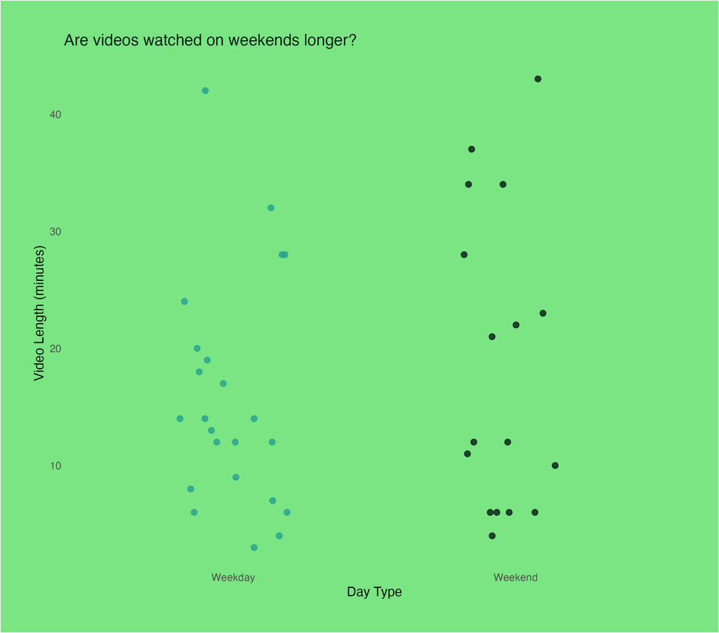

Scatter plot comparing video lengths watched on weekdays and weekends. Weekend viewing appears to include more longer videos overall, with several videos exceeding 30 minutes.

From this I can see that during the two periods of time preceding project 2 and project 4, I was watching Youtube slightly more and of longer videos on weekends given that weekends only consists of two days. This is not surprising as I usually have more time on the weekends to relax and less tasks to do.

## Are the ads even relevant?

As a non-youtube-premium user one is bombarded with ads. Are they even relevant to the video?

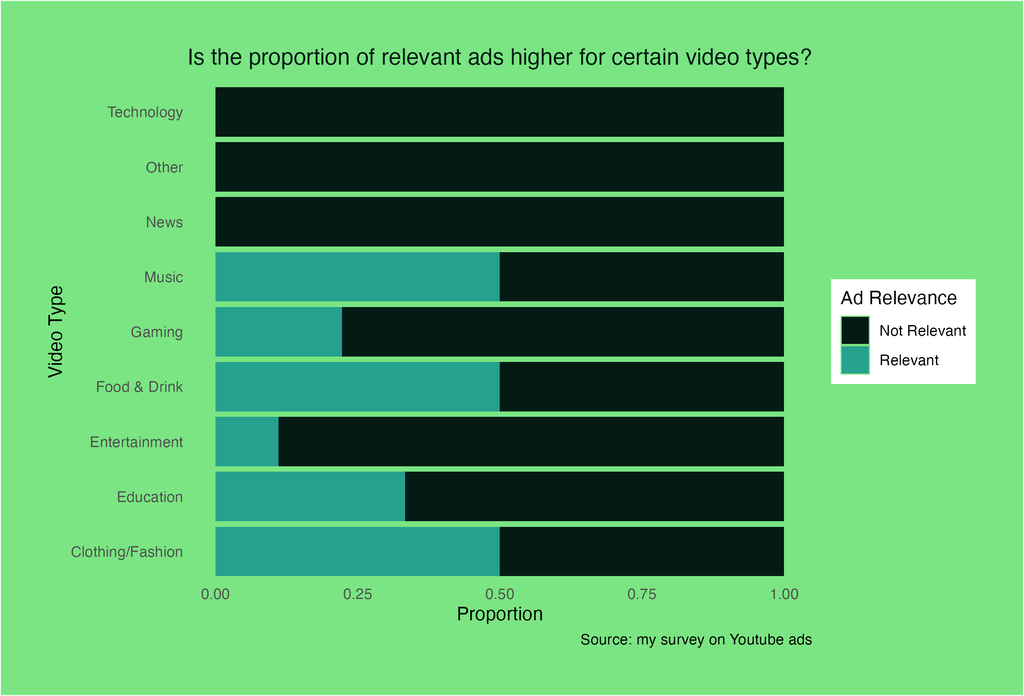

From the above data it seems the majority of the ads are irrelevant to the video. However 3 types seems to have more relevant ads, namely Music, Food & Drink, and Clothing/Fashion. One reason I can think for this is that they are everyday consumer interests and are therefore more likely to match the general themes of popular videos and user demographics.

## Spam of the skip button

Perhaps if the ad has a positive impression on me I won’t skip it?

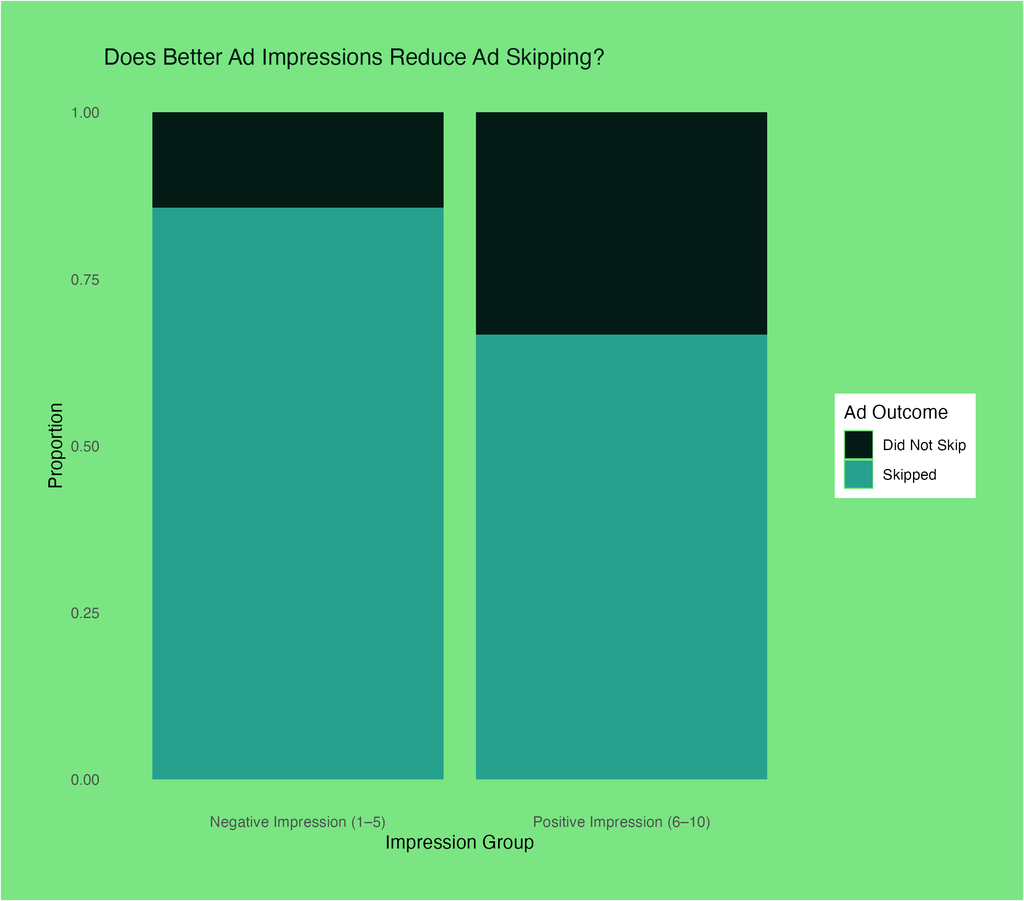

The proportion of videos I didn’t skip when I had a positive impression of the ad is certainly bigger. However I do know that this was usually due to them being ads of new products/companies I have not seen before so I was curious just to see what they’re trying to push.

## In conclusion

I should watch less Youtube videos and do more work. Youtube ads are somewhat irrelevant to the videos and don’t really work on me.

[figure not shown]

A meme showing a small tabby kitten lying down with wired earbuds in while staring at a phone. Contextual text of “Me consuming 6 different forms of media at the same time to eliminate the risk of a single thought occurring”